# Quiz 3

Broderick Prows

2/20/2020

1. Formulate a Statistical data model

We chose to do a Beta-Binomial statistical model. We let
$$Y \sim Binomial(n,\theta)$$
where n = number of students in the class and
$$\theta \sim Beta(a,b)$$
to be the porportion of students that notice baldness.

2. Define Prior Distribution
   $$\pi( \theta ) = beta(12, 10)$$
   We chose a = 12 and b = 10 because we think that a little more than half of the students will notice baldness, but we kept these values relatively low to let our data impact the posterior more.

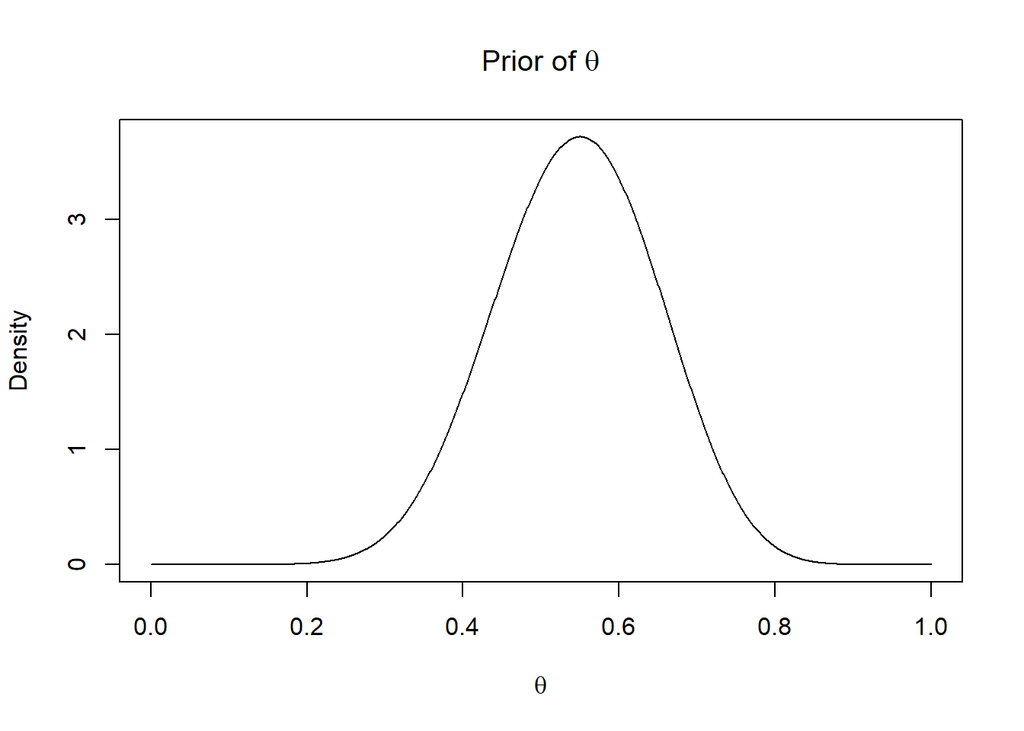

```r
thetas <- seq(0,1,length.out = 1001)
a <- 12
b <- 10
f_theta <- dbeta(thetas,shape1 = a, shape2 = b)
plot(thetas, f_theta, type = 'l', col = 'black',
     main = expression(paste('Prior of ', theta)),
     xlab = expression(theta), ylab = 'Density')
```

3. Find the Posterior

```r
y <- c(34,45,23,40,39,66,74,53,22,28,36,39,45,41,51)
n <- c(60,72,40,62,50,95,110,90,40,40,50,50,65,65,90)
a_star <- a + sum(y)
b_star <- b + sum(n) - sum(y)
print(paste("a* = ", a_star))
```

```
## [1] "a* =  648"
```

```r
print(paste("b* = ", b_star))
```

```
## [1] "b* =  353"
```

$$\pi(\theta | Y) \sim Beta(648,353)$$
95% Credible interval for theta

```r
interval <- qbeta(c(0.025,0.975), shape1= a_star, shape2 = b_star)
print(interval)
```

```
## [1] 0.6174971 0.6766504
```

There is a 95% probability that the true proportion of individuals that notice baldness when meeting someone is between 0.617 and 0.677

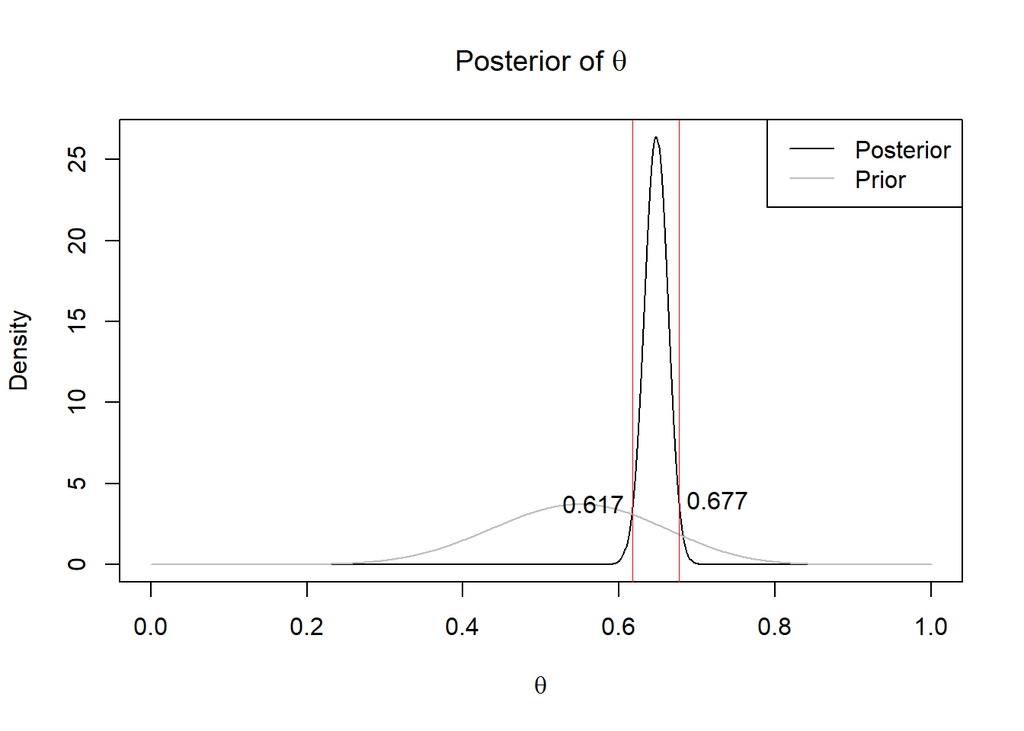

```r
f_theta_post <- dbeta(thetas,shape1 = a_star, shape2 = b_star)
plot(thetas, f_theta_post, type = 'l', col = 'black',
     main = expression(paste('Posterior of ', theta)),
     xlab = expression(theta), ylab = 'Density')
lines(thetas,f_theta,type = 'l',col='gray')
abline(v=interval, col = 'red', lwd = 0.5)
text(interval[1]-.05, dbeta(interval[1],a_star,b_star), round(interval[1], 3))
text(interval[2]+.05, dbeta(interval[2],a_star,b_star), round(interval[2], 3))
legend("topright", c("Posterior", "Prior"), col = c("black", "gray"), lty = 1)
```

4. Show that the posterior means is weighted average.

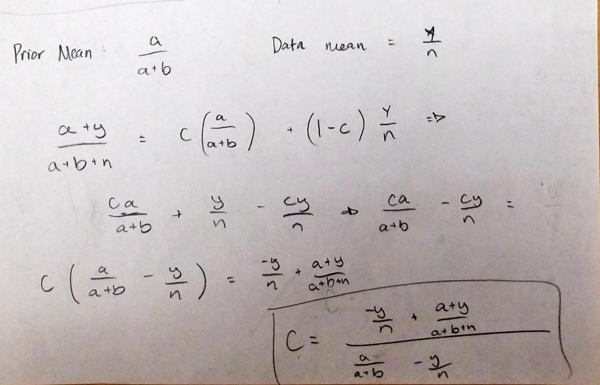

   Posterior mean is a weighted average.

5. Derive the Posterior Predictive

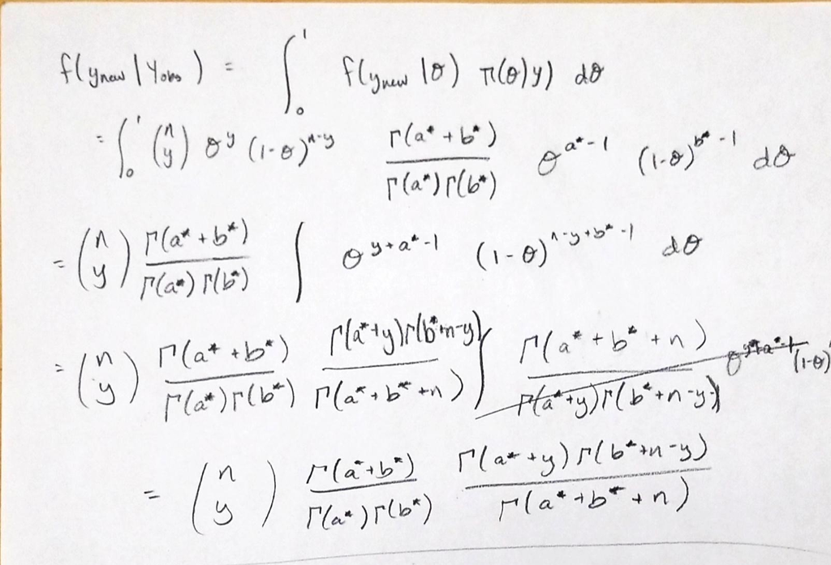

   Beta-Binomial Predictive